# QTM 151 - Quiz 4

## Try to submit as an HTML file

Print your name below

```python
# Write your answer here
print("Mary Mullinax")
```

```
Mary Mullinax
```

This quiz is open book

- You can use the lecture notes
- You will get partial credit for attempting the questions
- To get full credit, the code should run as intended
- You should NOT communicate with other students

Print the following message:

"I will abide by Emory's code of conduct"

```python
# Write your answer here:
print("I will abide by Emory's code of conduct")
```

```
I will abide by Emory's code of conduct
```

Import the libraries "matplotlib.pyplot" and "pandas"

```python
# Write your answer here

import pandas as pd
import matplotlib.pyplot as plt
```

In this quiz you will work with data on exchange rates,  
for the following currencies:

- 1 euro (EUR) to dollar (USD)
- 1 pound (GPB) to dollar (USD).

(a) Import and parse dates

- Import the dataset "currencies.csv"
- Parse the "date_string" column with `pd.to_datetime()`
- To get full points, set the "format" option using wildcards as in Lecture 16.

```python
currencies_df = pd.read_csv('data_raw/currencies.csv')
```

```python
# Write your own code
currencies_df['date'] = pd.to_datetime(currencies_df['date_string'], format='%A, %b %d, %Y')
print(currencies_df.head())
```

```
               date_string  eur_to_usd  gbp_to_usd       date
0     Monday, Jan 04, 1999      1.6581      1.1812 1999-01-04
1    Tuesday, Jan 05, 1999      1.6566      1.1760 1999-01-05
2  Wednesday, Jan 06, 1999      1.6547      1.1636 1999-01-06
3   Thursday, Jan 07, 1999      1.6495      1.1672 1999-01-07
4     Friday, Jan 08, 1999      1.6405      1.1554 1999-01-08
```

(b) Plot multiple time series

- Create a line plot plot which has the "gbp_to_usd" and "eur_to_usd" on the y-axis

and the date on the x-axis

- Label the x-axis, the y-axis, and the title
- Add a legend and set the names to "1 Euro to USD" and "1 GPB to USD"

Hint: See Lecture 18 for how to plot multiple columns  
Hint: Remember to include the legend names as a list `[...]`

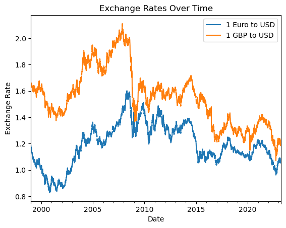

```python
# Write your own code
currencies_df[["date", "gbp_to_usd", "eur_to_usd"]]. set_index('date').plot()
plt.title('Exchange Rates Over Time')
plt.xlabel('Date')
plt.ylabel('Exchange Rate')
plt.legend(['1 Euro to USD', '1 GBP to USD'])
plt.show()
```

(c) Compute growth rates

- Calculate a new column "growth_euro" which computes the percentage daily

growth rate of "eur_to_usd".

Hint: Use `.diff()` and `.shift(1)`

```python
# Write your own code

currencies_df['growth_euro'] = currencies_df['eur_to_usd'].diff() / currencies_df['eur_to_usd'].shift(1) * 100
print(currencies_df[['date', 'eur_to_usd', 'growth_euro']].head())
```

```
        date  eur_to_usd  growth_euro
0 1999-01-04      1.6581          NaN
1 1999-01-05      1.6566    -0.090465
2 1999-01-06      1.6547    -0.114693
3 1999-01-07      1.6495    -0.314256
4 1999-01-08      1.6405    -0.545620
```

(d) Flag subset of data and plot

- Create a boolean colum (True/False) "bool_cond" which checks whether

"growth_euro" had a value greater than 2 or less than -2

- Generate a line plot with the "growth_euro" series, label the axes and the title
- Use the command `plt.fill_between()` as in Lecture 18 to create a shaded region

for time periods where "bool_cond" is true.

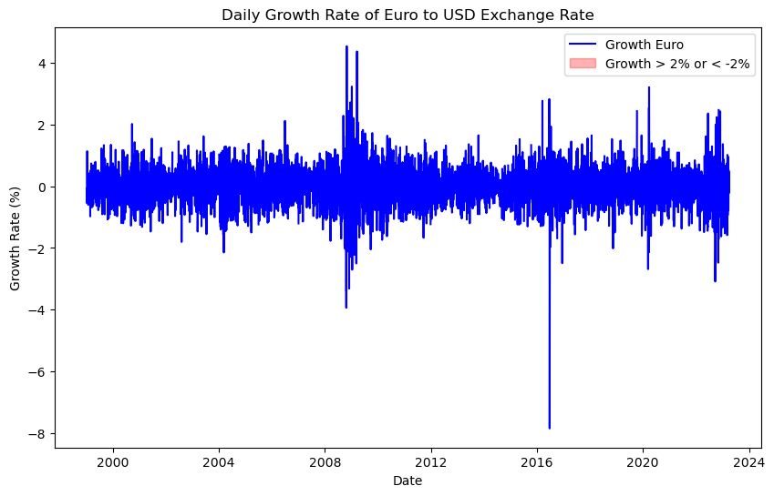

```python
# Write your own code
currencies_df['bool_cond'] = (currencies_df['growth_euro'] > 2) | (currencies_df['growth_euro'] < -2)

plt.figure(figsize=(10, 6))
plt.plot(currencies_df['date'], currencies_df['growth_euro'], label='Growth Euro', color='blue')

plt.fill_between(currencies_df['date'], currencies_df['growth_euro'], where=currencies_df['bool_cond'],
                color='red', alpha=0.3, label='Growth > 2% or < -2%')

plt.xlabel('Date')
plt.ylabel('Growth Rate (%)')
plt.title("Daily Growth Rate of Euro to USD Exchange Rate")
plt.legend()
plt.show()
```

(e) Aggregate dataset by time period

- Create an object "month_config" that uses `pd.Grouper()`, setting the key to

the column "date" and freq to "m" (month)

- Follow the instructions in Lecture 16 to compute an aggregate dataset

by month which computes the standard deviation of "eur_to_usd"

- Display the dataset

```python
month_config = pd.Grouper(key = 'date', freq='M')
currencies_df.groupby(month_config).agg('eur_to_usd').std()
```

```
date
1999-01-31    0.007345
1999-02-28    0.013345
1999-03-31    0.010475
1999-04-30    0.006172
1999-05-31    0.013046
                ...
2022-11-30    0.027308
2022-12-31    0.011389
2023-01-31    0.015046
2023-02-28    0.008972
2023-03-31    0.016246
Freq: ME, Name: eur_to_usd, Length: 291, dtype: float64
```

(f) Convert a dataset to long format

- Convert the currencies dataset to long format using the following inputs

```
var_name   = "type",
value_name = "exchange_rate",
id_vars    = "date",
value_vars = ["eur_to_usd","gbp_to_usd"]
```

- Display the dataset

Hint: See Lecture 18 for details on `pd.melt()`

```python
# Write your own code
currencies_long = pd.melt(currencies_df,
                             var_name = "type",
                             value_name = "exchange_rate",

                             id_vars=['date'],
                             value_vars=['eur_to_usd', 'gbp_to_usd'],)
print(currencies_long.head())
```

```
        date        type  exchange_rate
0 1999-01-04  eur_to_usd         1.6581
1 1999-01-05  eur_to_usd         1.6566
2 1999-01-06  eur_to_usd         1.6547
3 1999-01-07  eur_to_usd         1.6495
4 1999-01-08  eur_to_usd         1.6405
```